# Australian Resource Export Volumes

Quarterly nowcast — iron ore and coal

25 May 2026

## Headline nowcasts

Current quarter — June 2026 · 60% of the quarter observed

Iron ore

236.0Mt

80% CI · 232.6 – 238.8 Mt+0.0 Mt (+0.0%) vs the run 5 days ago

Metallurgical coal

38.2Mt

80% CI · 37.3 – 39.6 Mt+0.0 Mt (+0.0%) vs the run 5 days ago

Thermal coal

49.6Mt

80% CI · 47.3 – 51.9 Mt+0.0 Mt (+0.0%) vs the run 5 days ago

### Why the nowcast says what it says

Each headline above broken into additive contributions vs the seasonal-naive baseline (same quarter last year). All values in Mt; rows sum to the nowcast up to a small non-linearity in

```
exp(Δlog) −
1
```

| commodity | last year (V_{Q-4}) | tonnage signal | model anchor adj. | other | = nowcast |
| --- | --- | --- | --- | --- | --- |
| Iron ore | 238.7 Mt | -4.9 | +2.2 | +0.0 | 236.0 Mt |
| Metallurgical coal | 37.0 Mt | +1.6 | -0.4 | +0.0 | 38.2 Mt |
| Thermal coal | 47.8 Mt | +1.4 | +0.4 | +0.0 | 49.6 Mt |

### Next-quarter outlook · September 2026

Forecast for the quarter after the headline above, using seasonal PortWatch patterns + the most recent observed pace. Bands are wider by construction (no in-quarter observations to shrink them).

Iron ore · forecast

234.7Mt

80% CI · 229.2 – 239.1 Mt

Metallurgical coal · forecast

36.5Mt

80% CI · 35.0 – 38.5 Mt

Thermal coal · forecast

50.3Mt

80% CI · 46.7 – 54.0 Mt

## Nowcast vs recent actuals

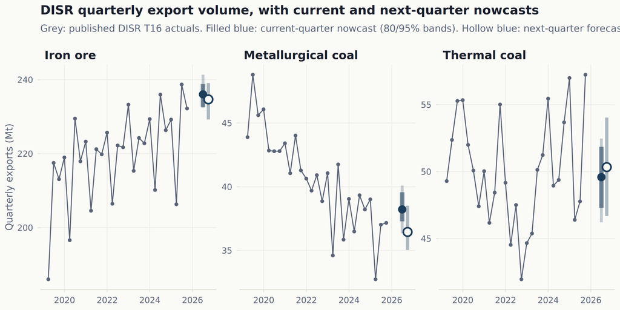

## Forecast vs actual — closed quarters

*No closed quarters with a prior in-window nowcast yet. Comparisons appear here once a quarter we nowcasted within 42 days of close has been published by DISR.*

## Band calibration

Empirical band coverage on backtest quarters, reconstructed at share_observed = 0 (full residual bootstrap, no in-quarter shrink). Well-calibrated bands produce values near 0.80 and 0.95. Combination specs (`equal_avg`, `inv_mse`) lack a single lm fit and are omitted.

| ★ | commodity | spec | n (OOS) | coverage 80% (target 0.80) | coverage 95% (target 0.95) |
| --- | --- | --- | --- | --- | --- |
|  | iron_ore | aggregate | 7 | 0.57 | 0.86 |
| ★ | iron_ore | bojo | 7 | 0.71 | 0.86 |
|  | iron_ore | lagged | 7 | 0.71 | 0.71 |
|  | iron_ore | midas | 7 | 0.71 | 0.71 |
|  | iron_ore | price_aug | 7 | 0.57 | 0.71 |
|  | coal_met | aggregate | 7 | 0.57 | 0.86 |
|  | coal_met | bojo | 7 | 0.71 | 0.71 |
|  | coal_met | lagged | 7 | 0.57 | 0.86 |
| ★ | coal_met | midas | 7 | 0.86 | 1.00 |
|  | coal_met | price_aug | 7 | 0.57 | 0.71 |
|  | coal_thermal | aggregate | 7 | 0.57 | 0.71 |
| ★ | coal_thermal | bojo | 7 | 0.86 | 0.86 |
|  | coal_thermal | lagged | 7 | 0.29 | 0.71 |
|  | coal_thermal | midas | 7 | 0.43 | 0.86 |
|  | coal_thermal | price_aug | 7 | 0.57 | 0.71 |

## Bridge diagnostics

★ marks the production-deployed spec per commodity (best of the candidate set + combinations by backtest RMSE). `R²` is in-sample, `R²_oos` is walk-forward out-of-sample. `p(β_lag4=1)` is the Wald-test p-value for the YoY-on-YoY restriction (NA for `bojo`, which imposes it; `equal_avg` and `inv_mse` are combination forecasts and have no in-sample β). `p(Chow)` tests for a structural break at the midpoint of the training sample; values < 0.05 suggest the AIS↔︎DISR relationship shifted within the fit window. `RMSE/naive` < 1 means the spec beats the seasonal random walk.

| ★ | commodity | spec | R² | R²_oos | β_T (se) | β_lag4 | p(β_lag4=1) | p(Chow) | rmse_valid | RMSE/naive |
| --- | --- | --- | --- | --- | --- | --- | --- | --- | --- | --- |
|  | iron_ore | aggregate | 0.91 | 0.83 | 0.477 (se 0.094) | 0.960 | 0.359 | 0.67 | 4.83 | 0.84 |
| ★ | iron_ore | bojo | 0.61 | 0.85 | 0.504 (se 0.094) |  |  | 0.81 | 4.51 | 0.78 |
|  | iron_ore | equal_avg |  | 0.83 |  |  |  |  | 4.85 | 0.84 |
|  | iron_ore | inv_mse |  | 0.83 |  |  |  |  | 4.79 | 0.83 |
|  | iron_ore | lagged | 0.87 | 0.75 | 0.482 (se 0.098) | 0.950 | 0.374 | 0.51 | 5.77 | 1.00 |
|  | iron_ore | midas | 0.92 | 0.84 | 0.467 (se 0.082) | 0.977 | 0.697 | 0.86 | 4.63 | 0.80 |
|  | iron_ore | price_aug | 0.91 | 0.83 | 0.470 (se 0.090) | 0.953 | 0.280 | 0.77 | 4.86 | 0.84 |
|  | coal_met | aggregate | 0.68 | 0.19 | 0.276 (se 0.143) | 0.779 | 0.059 | 0.54 | 1.84 | 0.82 |
|  | coal_met | bojo | 0.20 | 0.10 | 0.327 (se 0.136) |  |  | 0.76 | 1.94 | 0.86 |
|  | coal_met | equal_avg |  | 0.31 |  |  |  |  | 1.70 | 0.76 |
|  | coal_met | inv_mse |  | 0.49 |  |  |  |  | 1.46 | 0.65 |
|  | coal_met | lagged | 0.71 | -0.36 | 0.386 (se 0.160) | 0.805 | 0.099 | 0.36 | 2.38 | 1.06 |
| ★ | coal_met | midas | 0.76 | 0.71 | 0.223 (se 0.101) | 0.737 | 0.001 | 0.36 | 1.10 | 0.49 |
|  | coal_met | price_aug | 0.71 | 0.23 | 0.346 (se 0.128) | 0.742 | 0.016 | 0.19 | 1.79 | 0.80 |
|  | coal_thermal | aggregate | 0.68 | 0.41 | 1.098 (se 0.184) | 0.563 | 0.001 | 0.20 | 3.16 | 1.27 |
| ★ | coal_thermal | bojo | 0.76 | 0.71 | 1.340 (se 0.212) |  |  | 0.06 | 2.21 | 0.89 |
|  | coal_thermal | equal_avg |  | 0.61 |  |  |  |  | 2.57 | 1.03 |
|  | coal_thermal | inv_mse |  | 0.65 |  |  |  |  | 2.43 | 0.98 |
|  | coal_thermal | lagged | 0.79 | 0.50 | 1.172 (se 0.145) | 0.665 | 0.003 | 0.16 | 2.92 | 1.17 |
|  | coal_thermal | midas | 0.74 | 0.60 | 1.167 (se 0.180) | 0.690 | 0.011 | 0.61 | 2.61 | 1.05 |
|  | coal_thermal | price_aug | 0.70 | 0.46 | 1.031 (se 0.184) | 0.573 | 0.001 | 0.16 | 3.03 | 1.22 |

## Backtest — every spec, every quarter

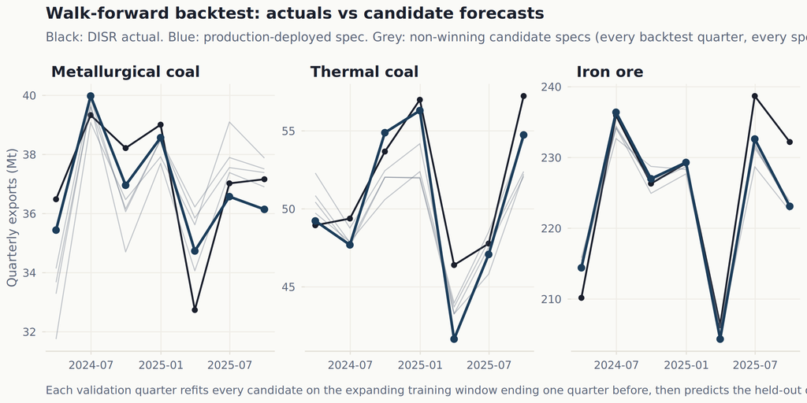

## PortWatch tonnage trend

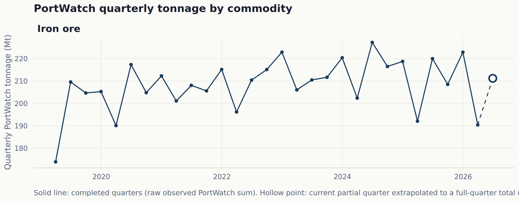

## Change since last run

Same-quarter run-over-run delta. Drops rows for any commodity whose current quarter has no prior nowcast.

| commodity | quarter_end | prior_Mt | now_Mt | delta_Mt | delta_pct | hours_since |
| --- | --- | --- | --- | --- | --- | --- |
| iron_ore | 2026-06-30 | 236.02 | 236.02 | 0 | 0 | 108.7 |
| coal_met | 2026-06-30 | 38.22 | 38.22 | 0 | 0 | 108.7 |
| coal_thermal | 2026-06-30 | 49.59 | 49.59 | 0 | 0 | 108.7 |

## Flagged anomalies

Largest |z|-score departures from the seasonal daily norm (±7-day window) in the last 28 days. Seasonal norm is built from training-window observations only; z > 0 is unusually busy, z < 0 unusually quiet.

| date | port | commodity | tonnage (kt) | expected (kt) | z |
| --- | --- | --- | --- | --- | --- |
| 2026-05-09 | port981 | iron_ore | 1115 | 524 | 3.96 |
| 2026-05-14 | port276 | iron_ore | 720 | 358 | 2.74 |
| 2026-05-06 | port276 | iron_ore | 45 | 378 | -2.26 |
| 2026-05-05 | port981 | iron_ore | 172 | 534 | -2.23 |
| 2026-05-02 | port458 | coal | 584 | 281 | 2.16 |

## Methodology

### Production equation per commodity

These are the actual equations driving the headline nowcast above. One per commodity, picked by walk-forward backtest RMSE from a bench of `{aggregate, midas, bojo, lagged, price_aug, demand_aug, equal_avg, inv_mse}` specs.

#### Iron ore — `bojo` spec

$$\Delta_{4}\log V_{Q} \;=\; 0.009 \;+
0.504 \,\Delta_{4}\log T_{Q} \;+\; \varepsilon_{Q}$$

Wald test of $\beta_{lag4}=1$: aggregate p = 0.36, midas p = 0.70. Restriction not rejected; pure YoY-on-YoY wins the OOS leaderboard at RMSE = 4.51 Mt (0.78× naive).

#### Metallurgical coal — `midas` spec

$$\log V_{Q} \;=\; 0.940 \;- 0.011
\,\Delta_{4}\log T_{Q,m1} \;+ 0.252 \,\Delta_{4}\log T_{Q,m2} \;- 0.019
\,\Delta_{4}\log T_{Q,m3} \;+ 0.737 \,\log V_{Q-4} \;+\;
\varepsilon_{Q}$$

Wald test of $\beta_{lag4}=1$: aggregate p = 0.06, midas p = 0.00. OOS RMSE = 1.10 Mt (0.49× naive); within-quarter monthly timing carries enough signal to justify the extra parameters.

#### Thermal coal — `bojo` spec

$$\Delta_{4}\log V_{Q} \;=\; 0.009 \;+
1.340 \,\Delta_{4}\log T_{Q} \;+\; \varepsilon_{Q}$$

### Conventions

- $V_{Q}$ is DISR Resources & Energy Quarterly Table 16 physical tonnage (Mt) for the commodity. Coal is metallurgical + thermal summed.
- $T_{Q}$ is PortWatch AIS daily tonnage summed across the commodity’s ports over quarter $Q$. The current-quarter partial-month scale-up anchors on the data’s latest observation date (not `Sys.Date()`), so PortWatch’s 7–14 day refresh lag doesn’t bias the estimate down.
- $\Delta_{4}$ is the year-on-year log difference. The YoY transform strips deterministic seasonality, so no explicit STL / X-13 step is needed at our sample size (n ≈ 23 quarters).
- Newey-West HAC standard errors with `lag = 1`. Uncertainty bands from residual bootstrap, scaled by $\sqrt{1 - \text{share\_observed}}$ so they collapse as the current quarter fills in.
- Full derivation, candidate bench, and the literature this draws on: [`docs/METHODOLOGY.md`](https://github.com/DavidAStephan/ResourceExplorer/blob/main/docs/METHODOLOGY.md).